# Exploration of Cases, ISS, Interventions

jaegerl

2025-03-07

## The Research Question

Main points: * The research question is something along the lines of `Does TBI affect the pathophysiology of polytrauma?`, understood as follows: Consider two polytrauma patients who both have the same clinical characteristics, including the types of injuries, but one patient has TBI and the other does not. How do the pathophysiological parameters of these two patients differ? * The population of interest the polytrauma population, defined by the the AIS (Abbreviated Injury Scale) system: Polytrauma corresponds to an AIS score of at least 3 in at least two body regions. * By “pathophysiological parameters”, we mean the degree of dysfunction in major systems involved in polytrauma (bleeding, coagulopathy, fever, soft tissue damage). * An important covariate will be the severity of the TBI. The idea is to quantify it by the degree of unconsciousness as measured by the Glasgow Coma Scale (GCS), the injury (presence/type of intracranial bleeding), and any (surgical) intervention. To this end, we are supposed to explore the various relationships between these variables.

Some thoughts on the research question: * If we really want to isolate the effect of TBI on the pathophysiology, we would need some controls in addition to the TBI patients, i.e., polytrauma patients without TBI. One idea could then be to quantify the TBI effect by using something like regression models, propensity score matching, and so on. * On the other hand, it might be really difficult to extract a reasonable control population, since we would have to take into account the location and severity of the injuries. However, this could be achieved with the AIS and the different body regions. * Alternatively, we could limit the analysis to patients with TBI and try to model the relationship between TBI severity and the pathophysiological parameters.

## Interventions

### Inspect Distribution

```r
# function for data import from .csv files
import_dataset <- function(...) {
  import_list(..., rbind = TRUE, setclass = "data.table")
}

# import cleaned interventions dataset
load(paste0(clean_path, "Interventions/interventions1_long.RData"))
load(paste0(clean_path, "Interventions/interventions1_wide.RData"))
load(paste0(clean_path, "Interventions/interventions2_long.RData"))
load(paste0(clean_path, "Interventions/interventions2_wide.RData"))

# see what kind of interventions are listed
table(interventions1_long$procedure, useNA = "always")
```

```
##
##        Korrektur Aneurysma/intrakranielle Gefässe
##                                                50
##                                Korrektur Bohrloch
##                                               235
##                    Korrektur Ekzision/Destruktion
##                                                42
##         Korrektur Hirnhäute/intrakranielle Nerven
##                                                20
##              Korrektur Intrakranielles Monitoring
##                                              1276
##              Korrektur Inzision an den Hirnhäuten
##                                               273
##                Korrektur Knocheneingriffe Schädel
##                                               124
##                Korrektur Kraniotomie/Kraniektomie
##                                               271
##              Korrektur Punktion/Drainage/Inzision
##                                                30
##                         Korrektur Ventrikelsystem
##                                                43
## Korrektur Zugänge zur Schädelbasis/Schädelkalotte
##                                                47
##                                              <NA>
##                                                 0
```

All of these interventions are surgeries of the brain or skull.

Check distribution/co-occurrence of interventions.

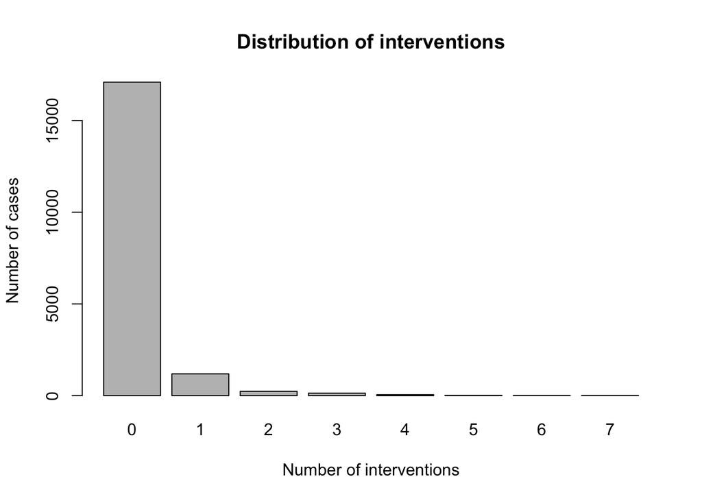

```r
# how many different interventions did the single cases receive?
barplot(height = table(rowSums(interventions1_wide[, -1])),
        main = "Distribution of interventions", xlab = "Number of interventions", ylab = "Number of cases")
```

Most of the enlisted cases did not receive any intervention at all.

### What are these interventions anyway?

```r
colnames(interventions1_wide)
```

```
##  [1] "research_case_id"
##  [2] "Korrektur Intrakranielles Monitoring"
##  [3] "Korrektur Aneurysma/intrakranielle Gefässe"
##  [4] "Korrektur Knocheneingriffe Schädel"
##  [5] "Korrektur Kraniotomie/Kraniektomie"
##  [6] "Korrektur Bohrloch"
##  [7] "Korrektur Zugänge zur Schädelbasis/Schädelkalotte"
##  [8] "Korrektur Inzision an den Hirnhäuten"
##  [9] "Korrektur Punktion/Drainage/Inzision"
## [10] "Korrektur Ventrikelsystem"
## [11] "Korrektur Ekzision/Destruktion"
## [12] "Korrektur Hirnhäute/intrakranielle Nerven"
```

```r
# these are typical neurosurgical interventions for TBI patients
# for the dataset interventions2, let's see what the codes in the raw dataset were
interventions2 <- import_dataset(paste0(import_path,
                                        "[SDS].[v_Export_Procedure_Drg_tra_sds].csv"))
n_distinct(interventions2$Name)
```

```
## [1] 4102
```

```r
# ok, these are way too many. let's inspect them
intervention_names <- interventions2 |>
  select(Name) |>
  distinct() |>
  arrange(Name)
```

Indeed, `interventions2` includes all forms of surgical procedures, non-surgical procedures, imaging studies (CT and MRI).

### Compare with (Included) Cases

What are the cases in this table anyway? Let’s compare with the dataset of cases.

```r
# load cases (the spreadsheet has a few weird sheets)
diagnoses <- suppressWarnings(import_list(paste0(import_path, "Diagnosen.xlsx"),
                                          setclass = "data.table",
                                          guess_max = 50000))
# split into what could be relevant
diaglist <- diagnoses[[1]]
cases <- diagnoses[[2]]
included_cases <- diagnoses[[3]]
# make column names consistent
colnames(included_cases)[1] <- "research_case_id"
colnames(cases)[1] <- "research_case_id"
# remove the "Grand Total" observation
cases <- cases[research_case_id != "Grand Total"]

# what is the difference between cases (Pivot Table) and included cases (Pivottable nur Eingeschlossene)?
# inspect duplicates
nrow(included_cases[, .(n = .N), by = .(research_case_id)][n > 1])
```

```
## [1] 0
```

```r
nrow(cases[, .(n = .N), by = .(research_case_id)][n > 1])
```

```
## [1] 0
```

```r
# there are no duplicated entries. are all cases of included_cases also in the cases dataset?
sum(!(included_cases$research_case_id %in% cases$research_case_id))
```

```
## [1] 0
```

```r
# ok, this means that we can introduce a label for included cases in the cases dataset
cases[, included := as.numeric(research_case_id %in% included_cases$research_case_id)]
# for some reason, "Blutung korrigiert" and "Fraktur korrigiert" are not present in the cases dataset.
identical(cases[included == 1, -c("included", "Blutung korrigiert", "Fraktur korrigiert")],
          included_cases)
```

```
## [1] TRUE
```

```r
# at least, the datasets are consistent.

# how many cases did not receive any intervention at all?
noint <- interventions1_wide[rowSums(interventions1_wide[, -1]) == 0]
nrow(noint)
```

```
## [1] 17089
```

```r
# well, actually most of the cases had no intervention!

# how many of the included cases are not in the interventions dataset and vice versa?
cat(paste0("case with documentation of interventions, but not among included patients: ",
           nrow(included_cases[!(research_case_id %in% interventions1_wide$research_case_id)])))
```

[output not shown]

```r
cat(paste0("case of an included patient, but with no documentation of intervention: ",
           nrow(interventions1_wide[!(research_case_id %in% included_cases$research_case_id)])))
```

[output not shown]

```r
# do the IDs of the first and second sheet match?
length(setdiff(cases$research_case_id, diaglist$research_case_id))
```

```
## [1] 0
```

```r
length(setdiff(diaglist$research_case_id, cases$research_case_id))
```

```
## [1] 0
```

```r
# ok, so the first sheet contains the diagnoses of all cases in the second sheet.
# what about the third sheet: are there any cases that are not present in the second sheet?
length(setdiff(included_cases$research_case_id, cases$research_case_id))
```

```
## [1] 0
```

```r
# nice, so "Pivot Table nur Eingeschlossene" is a subset of "Pivot Table"
```

This is weird: The interventions dataset contains 18727 cases, while the included patients dataset contains 7156. What is the difference between the two? However, it could be that the interventions dataset only considers the first case for each patient. To check this, we need the patients IDs.

```r
patients <- import_dataset(paste0(import_path,
                                  "[SDS].[v_Export_Patient_Unfall_SpitalAufenthalt_tra_sds].csv"))
# get patients with multiple cases
mult_cases <- patients[, .(n_cases = .N,
                           research_case_id),
                       by = .(research_id)
][n_cases > 1]
# count the number of cases with documented intervention that belong to patients
# with multiple cases
sum(interventions1_wide$research_case_id %in% mult_cases$research_case_id)
```

```
## [1] 6312
```

```r
# ok, the interventions are definitely not documented for patients with one single
# case only...
```

OK, so this is not the case…

### What do the Variables Mean?

It seems like `Sum of Blutung` counts the types of intracranial hemorrhage present in every case. Is this consistent with the entries in the corresponding columns?

```r
test <- cases[`Sum of Blutung` != `Sum of Subduralblutung` +
                `Sum of Epiduralblutung` +
                `Sum of Subarachnoidalblutung` +
                `Sum of Andere Blutungen`]
nrow(test)
```

```
## [1] 901
```

```r
# well, it's not. maybe they added other columns?
test <- cases[`Sum of Blutung` != `Sum of Subduralblutung` +
                `Sum of Epiduralblutung` +
                `Sum of Subarachnoidalblutung` +
                `Sum of Andere Blutungen` +
                `Sum of Kontusion` +
                `Sum of Diffuse Hirnverletzungen und Riss/Shearing`]
nrow(test)
```

```
## [1] 0
```

```r
# what?! they also added brain injury to intracranial bleeding?
# are the presence indicators at least consistent?
sum(cases$`Blutung korrigiert Ja/Nein` != as.numeric(cases$`Sum of Blutung` > 0))
```

```
## [1] 0
```

```r
# this is consistent
sum(cases$`Fraktur korrigiert Ja/Nein` != as.numeric(cases$`Sum of Fraktur` > 0))
```

```
## [1] 0
```

```r
# this is also consistent.

# are there any redundant columns?
sum(cases$`Sum of Blutung` != cases$`Blutung korrigiert`)
```

```
## [1] 0
```

```r
# ok, these two columns are the same.
sum(cases$`Sum of Fraktur` != cases$`Fraktur korrigiert`)
```

```
## [1] 0
```

```r
# these too.

# are fractures at least consistently defined, as basilar (Schädelbasis) and/or vault (Schädelkalotte) fractures?
nrow(cases[`Sum of Fraktur` != `Sum of Schädelbasisfraktur` +
             `Sum of Schädelkalottenfaktur`])
```

```
## [1] 0
```

```r
# they are!
```

### ISS and AIS scores

Let’s check the consistency of the values in the AIS and ISS datasets.

```r
# import the ISS scores
load(paste0(clean_path, "iss_clean.RData"))

# check the distribution of ISS values
summary(iss_clean$iss)
```

```
##    Min. 1st Qu.  Median    Mean 3rd Qu.    Max.
##   0.000   4.000   4.000   6.455   9.000  50.000
```

```r
# I thought the minimum possible value was 1? how come?

# let's first check who these patients are.
# how many cases have na ISS but no intervention and vice versa?
cat(paste0("ISS, but no intervention: ",
           sum(!(iss_clean$research_case_id %in%
                   interventions1_wide$research_case_id))))
```

```
## ISS, but no intervention: 762
```

```r
cat(paste0("Intervention, but no ISS: ",
           sum(!(interventions1_wide$research_case_id %in%
                   iss_clean$research_case_id))))
```

```
## Intervention, but no ISS: 2275
```

```r
# this is so strange... are the ones without interventions also the ones with
# zero ISS?
nrow(iss_clean[iss == 0])
```

```
## [1] 1133
```

```r
nrow(iss_clean[!(research_case_id %in% interventions1_wide$research_case_id)])
```

```
## [1] 762
```

```r
# there seems to be no relationship.

# is there a documented ISS at least for all included cases?
nrow(included_cases[!(research_case_id %in% iss_clean$research_case_id)])
```

```
## [1] 34
```

```r
# there is a very small number of included cases without ISS. maybe we can
# just neglect these.
```

Can we at least replicate the calculation of the ISS values from the AIS scores?

```r
# AIS scores of the individual patients.
ais_mapping <- import_dataset(paste0(import_path,
                                     "[SDS].[v_Export_Mapping_Diagnosen_ICD_to_AIS_tra_sds].csv"))
table(ais_mapping$MAX_AIS_SEVERITY)
```

```
##
##     0     1     2     3     4     5     6
##  3384 20157 26506  7925    53   138     1
```

```r
# this column seems to contain the AIS values
table(ais_mapping$AIS_CHAPTER)
```

```
##
##    -1     0     1     2     3     4     5     6     7     8     9
##  2886   131 16995  5949   216  4679  1627  5053  8705 11449   474
```

```r
# this one seems to contain the body AIS region, but what is -1?
ais_mapping[AIS_CHAPTER == -1, (DESCRIPTION)] |>
  unique() |>
  head(20)
```

```
##  [1] "Failed or difficult intubation"
##  [2] "Blister (nonthermal) of foot"
##  [3] "Other specified complications of internal orthopedic prosthetic devices, implants and grafts"
##  [4] "Other complications of procedures, not elsewhere classified"
##  [5] "Infection following a procedure"
##  [6] "Other specified complications of cardiac and vascular prosthetic devices, implants and grafts"
##  [7] "Disruption of wound, not elsewhere classified"
##  [8] "Infection and inflammatory reaction due to internal fixation device"
##  [9] "Infection and inflammatory reaction due to prosthetic device, implant and graft in urinary system"
## [10] "Poisoning by, adverse effect of and underdosing of other systemic antibiotics"
## [11] "Infection and inflammatory reaction due to other cardiac and vascular devices, implants and grafts"
## [12] "Mechanical complication of internal fixation device of other bones"
## [13] "Mechanical complication of internal fixation device of bones of limb"
## [14] "Mechanical complication of other cardiac and vascular devices and implants"
## [15] "Other complications following infusion, transfusion and therapeutic injection"
## [16] "Poisoning by, adverse effect of and underdosing of cardiac-stimulant glycosides and drugs of similar action"
## [17] "Mechanical complication of gastrointestinal prosthetic devices, implants and grafts"
## [18] "Vascular complications following infusion, transfusion and therapeutic injection"
## [19] "Infection and inflammatory reaction due to internal joint prosthesis"
## [20] "Mechanical complication of internal joint prosthesis"
```

```r
# these are general/diffuse problems, not localized traumas. do these also carry
# scores like the other chapters?
ais_mapping[AIS_CHAPTER == -1, (MAX_AIS_SEVERITY)] |>
  table(useNA = "always")
```

```
##
##    0 <NA>
## 2886    0
```

```r
# interesting - these only carry values of zero - they are irrelevant for the
# calculation of the ISS!
# is the converse also true, do the patients with an ISS of zero only have
# AIS scores in chapter -1? let us check if AIS values of zero are possible
# outside chapter -1:
ais_mapping[AIS_CHAPTER != -1 & MAX_AIS_SEVERITY == 0,
            .(AIS_CHAPTER,
              DESCRIPTION)] |>
  head(20)
```

```
##     AIS_CHAPTER
##           <int>
##  1:           7
##  2:           1
##  3:           7
##  4:           7
##  5:           1
##  6:           8
##  7:           1
##  8:           7
##  9:           4
## 10:           7
## 11:           7
## 12:           1
## 13:           1
```

[output cut: 31 more lines]

```r
# this makes no sense - why are there values of zero? I thought the minimum
# possible value was 1?

# for calculation of ISS scores, note that one does NOT use the usual AIS regions,
# but 6 unions of AIS regions, which are then called "ISS regions". these are probably
# encoded in the ISS_BODY_REGION column:
table(ais_mapping$ISS_BODY_REGION, useNA = "always")
```

```
##
##     0     1     2     3     4     5     6  <NA>
##  2886 15363  5670  2744 14989  4763 11749     0
```

```r
# again, there is a region zero - is this equivalent to AIS region -1?
unique(ais_mapping[, .(ISS_BODY_REGION, AIS_CHAPTER)]
       )[order(ISS_BODY_REGION, AIS_CHAPTER)]
```

```
##     ISS_BODY_REGION AIS_CHAPTER
##               <int>       <int>
##  1:               0          -1
##  2:               1           0
##  3:               1           1
##  4:               1           3
##  5:               1           4
##  6:               1           6
##  7:               2           0
##  8:               2           4
##  9:               2           6
## 10:               3           5
## 11:               3           6
## 12:               4           7
## 13:               4           8
## 14:               5           2
## 15:               6           0
## 16:               6           1
## 17:               6           2
## 18:               6           3
## 19:               6           4
## 20:               6           5
## 21:               6           7
## 22:               6           8
## 23:               6           9
##     ISS_BODY_REGION AIS_CHAPTER
```

```r
# let's inspect in more detail
ais_mapping[ISS_BODY_REGION == 6, .(DESCRIPTION,
                                    ISS_BODY_REGION,
                                    AIS_CHAPTER)] |>
  unique() |>
  head(20)
```

```
##                                                      DESCRIPTION
##                                                           <char>
##  1:                                       Contusion of lower leg
##  2:                                          Open wound of scalp
##  3:                                           Contusion of thigh
##  4:                                        Abrasion of lower leg
##  5:          Unspecified superficial injury of unspecified thigh
##  6:                 Unspecified open wound of other part of head
##  7:                               Abrasion of other part of head
##  8: Contusion of other specified part of neck, initial encounter
##  9:                                          Open wound of elbow
## 10:                                          Contusion of thorax
## 11:                     Open wound of toe without damage to nail
## 12:                                          Abrasion of forearm
## 13:                             Abrasion of front wall of thorax
```

[output cut: 31 more lines]

```r
# ok, this may make sense: external wounds are collected in ISS chapter 6,
# and these can affect any region of the body!

# calculate ISS values
ais_values <- ais_mapping[, .(research_case_id,
                              MAX_AIS_SEVERITY,
                              ISS_BODY_REGION)] |>
  unique()
# keep highest AIS value for each body region
ais_values <- ais_values[, ais_max := max(MAX_AIS_SEVERITY),
                         by = .(research_case_id,
                                ISS_BODY_REGION)
                         ][ais_max == MAX_AIS_SEVERITY]
ais_values <- unique(ais_values[, .(research_case_id,
                                    ISS_BODY_REGION,
                                    ais_max)])
# keep three regions with highest scores
ais_values[, ais_rank := rank(-ais_max, ties.method = "random"),
           by = .(research_case_id)]
ais_values <- ais_values[ais_rank %in% 1:3]
# count number of worst regions for every case
ais_values[, n_regions := .N,
           by = .(research_case_id)]
# calculate ISS
ais_values[, iss_calc := sum(ais_max^2),
           by = .(research_case_id)]

# check with clean ISS data set
iss_compare <- merge(iss_clean,
                     y = ais_values[, .(research_case_id,
                                        iss_calc,
                                        n_regions)] |>
                       unique(),
                     by = "research_case_id",
                     all.x = TRUE)
# how many discrepancies?
nrow(iss_compare[iss != iss_calc])
```

```
## [1] 0
```

```r
# yay, the values match!
```

## Overview of Case IDs

How large are the discrepancies in the ID variable `research_case_id` between the different datasets?

```r
datasets <- list(all_cases = cases,
                 included_cases = included_cases,
                 interventions = interventions1_wide,
                 iss = iss_clean) |>
  lapply(`[[`, "research_case_id")
# what are the total numbers of IDs?
sapply(datasets, length)
```

```
##      all_cases included_cases  interventions            iss
##          19698           7156          18727          17214
```

```r
# how large are the mismatches?
mismatch_table <- sapply(datasets,
                         \(indices1) {
                           sapply(datasets,
                                  \(indices2) length(setdiff(indices1,
                                                             indices2)))
                         })
mismatch_table
```

```
##                all_cases included_cases interventions   iss
## all_cases              0              0             1     0
## included_cases     12542              0         11825 10092
## interventions        972            254             0   762
## iss                 2484             34          2275     0
```

Reading example: Among the `included_cases`, there are 254 IDs with no documented interventions, and 34 IDs with no documented ISS.